# TCGA colorectal cancer: tumour mutational burden from expression and methylation

Supervised shared-factor model — data processing, training, prediction, interpretation, and comparison

**Question.** How well do gene expression and promoter DNA methylation predict tumour mutational burden (TMB) in colorectal cancer, and which coordinated expression–methylation programmes drive the prediction?

**Data.** TCGA colon and rectal adenocarcinoma (COAD/READ), PanCancer Atlas 2018 release from cBioPortal (`data/tcga/coadread_tcga_pan_can_atlas_2018`). Two data views — RNA-seq gene expression and TSS200 promoter methylation — and the outcome $y = \log(1 + \text{TMB})$, where TMB is the number of nonsynonymous mutations per megabase.

**Model.** The supervised shared-factor model (`SupMultiviewShared`): each view $X^{(l)}$ is explained by shared factor scores $Z$ through view-specific loadings, $\mathbf x_i^{(l)} = \Lambda^{(l)}\mathbf z_i + \boldsymbol\epsilon_i^{(l)}$, and the outcome is $y_i = \boldsymbol\beta^\top\mathbf z_i + e_i$, so the factors are shaped by both views and the outcome. Notation follows `docs/main(1).tex`; metric definitions are in `docs/evaluation_metrics.md`.

**Where things are.** This is a real-data analysis, kept apart from the simulations: inputs come from `data/`, and every output of this notebook is written to `analysis/tcga_coadread/results/` (tables, fitted model) and `analysis/tcga_coadread/figures/` (plots). The comparison with other methods over several train/test splits is run by `compare_methods.py` in this folder.

## Setup

```python
import os
import sys
import importlib

os.environ["R_HOME"] = "/Library/Frameworks/R.framework/Resources"
sys.path.insert(1, os.path.expanduser("~/multiomic_integration/python"))
for _mod in ("coadread_data", "multiview_shared", "run_methods", "handler",
             "data_utils", "constants", "factor_interpretation"):
    if _mod in sys.modules:
        importlib.reload(sys.modules[_mod])

import numpy as np
import pandas as pd
import torch
import pyro
import seaborn as sns
import matplotlib.pyplot as plt
from scipy.stats import spearmanr

from coadread_data import load_coadread, make_view_list, make_feature_names
from run_methods import process_data, train_model, train_model_locally
from factor_interpretation import (
    summarize_factors, plot_pve, plot_factor_loadings, plot_factor_features,
    plot_factor_outcome, tabulate_top_features, factor_strength,
)
from data_utils import summarise_post_samples
from constants import Sites, Params

HERE     = os.path.expanduser("~/multiomic_integration/analysis/tcga_coadread")
RESULTS  = os.path.join(HERE, "results")
FIGURES  = os.path.join(HERE, "figures")
CLINICAL = os.path.expanduser("~/multiomic_integration/data/tcga/coadread_tcga_pan_can_atlas_2018")
os.makedirs(RESULTS, exist_ok=True)
os.makedirs(FIGURES, exist_ok=True)

def save_fig(fig, name):
    fig.savefig(os.path.join(FIGURES, name), dpi=150, bbox_inches="tight")

def save_table(df, name, index=True):
    df.to_csv(os.path.join(RESULTS, name), index=index)
    return df
```

## Settings

```python
VIEWS        = ["expr", "meth_tss200"]
VIEW_NAMES   = ["Expression", "TSS200 methylation"]
N_RNA_GENES  = 2000        # most variable expression genes (chosen on training samples)
N_METH_GENES = 1000        # most variable TSS200 methylation genes
SPLIT_SEED   = 42          # the train/test split (also split 1 of compare_methods.py)
K            = 20          # factors fitted; the shrinkage prior switches off unneeded ones
N_POSTERIOR_SAMPLES = 300
VERBOSE      = False

MODEL_CONFIG = {"k": K, "dense_model": False, "outcome_weight": 1.0}
TRAIN_CONFIG = {
    "eta":                   0.25,
    "delta":                 1e-16,
    "t":                     0.1,
    "num_particles":         1,
    "minibatch_fraction":    0.15,
    "min_epochs":            200,     # convergence_check.py: most of the loss decrease is over by 200
    "max_epochs":            2000,
    "convergence_criterion": "elbo_snr",
    "window":                50,
    "snr_threshold":         2,
}
SAVE_STEM = os.path.join(RESULTS, f"model_{'_'.join(VIEWS)}_k{K}")
```

## 1. Data

### Loading and preprocessing

```python
data = load_coadread(top_rna_genes=N_RNA_GENES, top_meth_genes=N_METH_GENES,
                     log1p_tmb=True, train_frac=0.8, random_seed=SPLIT_SEED,
                     preprocess_on_train_only=True)
gene_names = make_feature_names(data, VIEWS)

n_train, n_test = len(data["sample_ids_train"]), len(data["sample_ids_test"])
print(f"Samples: {n_train + n_test} ({n_train} train, {n_test} test)")
for name, X, genes in zip(VIEW_NAMES, make_view_list(data, VIEWS, "train"), gene_names):
    n_unique = len(set(genes))
    print(f"  {name}: {X.shape[1]} features"
          + (f" ({X.shape[1] - n_unique} gene symbols appear twice in the source file)"
             if n_unique < X.shape[1] else ""))
pd.Series(data["overlap_summary"], name="genes").to_frame()
```

```
Samples: 530 (424 train, 106 test)
  Expression: 2002 features (3 gene symbols appear twice in the source file)
  TSS200 methylation: 1000 features
```

|  | genes |
| --- | --- |
| n_rna_genes | 20511 |
| n_tss200_genes | 3163 |
| n_body_genes | 3073 |
| n_rna_tss200 | 3143 |
| n_rna_body | 3032 |
| n_all_three | 670 |

### Clinical variables

Clinical variables are not used by the model; they are joined here to describe the cohort and to interpret the factors. MSI status uses the MANTIS score thresholds suggested by cBioPortal (MSI > 0.6, indeterminate 0.4–0.6, stable < 0.4).

```python
samples = pd.read_csv(os.path.join(CLINICAL, "data_clinical_sample.txt"), sep="\t", skiprows=4)
patients = pd.read_csv(os.path.join(CLINICAL, "data_clinical_patient.txt"), sep="\t", skiprows=4)
clin = (samples[["SAMPLE_ID", "PATIENT_ID", "CANCER_TYPE_DETAILED", "TISSUE_SOURCE_SITE_CODE",
                 "ANEUPLOIDY_SCORE", "MSI_SCORE_MANTIS", "MSI_SENSOR_SCORE", "TMB_NONSYNONYMOUS"]]
        .merge(patients[["PATIENT_ID", "SUBTYPE", "SEX", "AGE"]], on="PATIENT_ID", how="left")
        .set_index("SAMPLE_ID"))
clin["MSI_STATUS"] = pd.cut(clin["MSI_SCORE_MANTIS"], [-np.inf, 0.4, 0.6, np.inf],
                            labels=["stable", "indeterminate", "MSI"])
clin["SITE"] = clin["CANCER_TYPE_DETAILED"].str.replace(" Adenocarcinoma", "")
clin["split"] = "train"
clin.loc[clin.index.isin(data["sample_ids_test"]), "split"] = "test"
clin = clin.loc[data["sample_ids_train"] + data["sample_ids_test"]]
clin["log1p_TMB"] = np.log1p(clin["TMB_NONSYNONYMOUS"])

cohort = pd.concat({
    "n": clin.groupby("split").size(),
    "TMB median": clin.groupby("split")["TMB_NONSYNONYMOUS"].median(),
    "MSI (%)": clin.groupby("split")["MSI_STATUS"].apply(lambda s: 100 * (s == "MSI").mean()),
    "rectal (%)": clin.groupby("split")["SITE"].apply(lambda s: 100 * s.str.contains("Rectal").mean()),
    "age median": clin.groupby("split")["AGE"].median(),
}, axis=1).round(1)
save_table(cohort, "cohort_summary.csv")
```

| split | n | TMB median | MSI (%) | rectal (%) | age median |
| --- | --- | --- | --- | --- | --- |
| test | 106 | 3.7 | 12.3 | 20.8 | 67.0 |
| train | 424 | 3.5 | 12.0 | 27.4 | 67.0 |

```python
save_table(pd.crosstab(clin["SUBTYPE"].fillna("missing"), clin["split"]), "subtype_counts.csv")
```

| split SUBTYPE | test | train |
| --- | --- | --- |
| COAD_CIN | 49 | 177 |
| COAD_GS | 10 | 39 |
| COAD_MSI | 12 | 48 |
| COAD_POLE | 3 | 3 |
| READ_CIN | 13 | 89 |
| READ_GS | 1 | 8 |
| READ_MSI | 1 | 2 |
| READ_POLE | 2 | 2 |
| missing | 15 | 56 |

### The outcome

TMB is heavily right-skewed: most tumours carry a few mutations per megabase, while a hypermutated minority — mostly microsatellite-unstable (MSI) tumours — carry tens to hundreds. The log transform makes the outcome closer to the Gaussian model’s assumption; the strong link to MSI status is what the model should be able to pick up from expression and methylation.

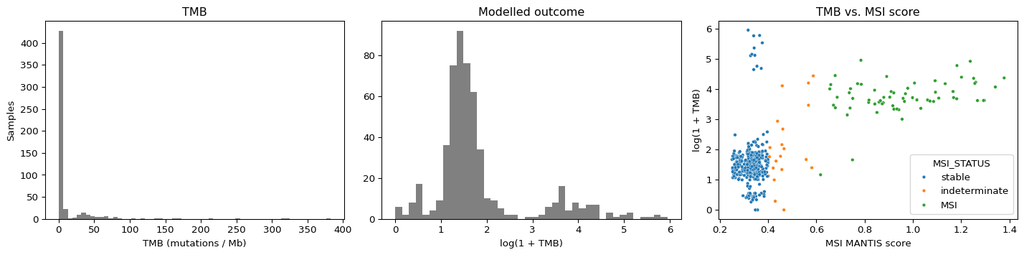

```python
fig, axes = plt.subplots(1, 3, figsize=(15, 3.8))
axes[0].hist(clin["TMB_NONSYNONYMOUS"], bins=60, color="gray")
axes[0].set(xlabel="TMB (mutations / Mb)", ylabel="Samples", title="TMB")
axes[1].hist(clin["log1p_TMB"], bins=40, color="gray")
axes[1].set(xlabel="log(1 + TMB)", title="Modelled outcome")
sns.scatterplot(data=clin, x="MSI_SCORE_MANTIS", y="log1p_TMB", hue="MSI_STATUS",
                s=12, ax=axes[2])
axes[2].set(xlabel="MSI MANTIS score", ylabel="log(1 + TMB)", title="TMB vs. MSI score")
plt.tight_layout()
save_fig(fig, "outcome_distribution.png")
plt.show()
```

### The views

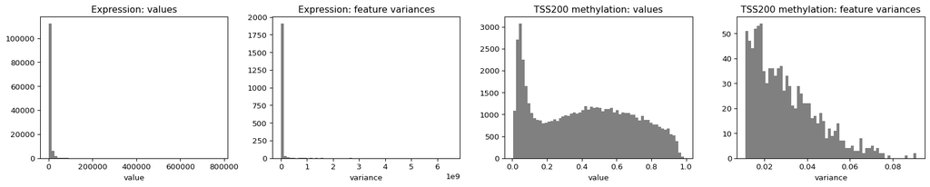

```python
fig, axes = plt.subplots(1, 4, figsize=(17, 3.5))
for v, (X, name) in enumerate(zip(make_view_list(data, VIEWS, "train"), VIEW_NAMES)):
    vals = X.numpy()
    axes[2 * v].hist(vals.ravel()[::7], bins=60, color="gray")
    axes[2 * v].set(title=f"{name}: values", xlabel="value")
    axes[2 * v + 1].hist(vals.var(axis=0), bins=60, color="gray")
    axes[2 * v + 1].set(title=f"{name}: feature variances", xlabel="variance")
plt.tight_layout()
save_fig(fig, "view_distributions.png")
plt.show()
```

## 2. Processing for the model

`process_data` prepares the views the same way as for every model and comparison method: drops all-zero columns, standardises each feature to mean 0 and sd 1 using training statistics (applied unchanged to the test samples), and standardises the outcome the same way. Predictions are transformed back to the log(1 + TMB) scale for reporting.

```python
real = lambda split, y: {"X_l": make_view_list(data, VIEWS, split=split), "y": y,
                         "K": torch.tensor(K), "Z": None}
train_subset, test_subset, dp = process_data(
    real("train", data["y"]), real("test", data["y_test"]), model_type="shared")
y_mean, y_sd = float(data["y"].mean()), float(data["y"].std())
feature_names = [[g for g, keep in zip(genes, f.tolist()) if keep]
                 for genes, f in zip(gene_names, dp["X_l_list_column_filters"])]
print("Model input:", [tuple(x.shape) for x in dp["train_X_l_list_clean"]],
      "train;", [tuple(x.shape) for x in dp["test_X_l_list_clean"]], "test")
```

```
Model input: [(424, 2002), (424, 1000)] train; [(106, 2002), (106, 1000)] test
```

## 3. Training

The model is fitted to the training samples by stochastic variational inference, starting from the SVD of the stacked views. Training runs for at least `min_epochs` epochs and then stops when the loss has stopped improving relative to its noise (`elbo_snr`). `min_epochs = 200` comes from `convergence_check.py` (section 3b): with the stopping rule alone the fit stopped near epoch 100, while the loss was still falling steeply; by epoch 200 most of the decrease is over (a further 9% by epoch 1 600, with no change in test R²). The fitted model is saved to `results/` (see *Saved outputs*).

```python
pyro.clear_param_store()
pyro.set_rng_seed(SPLIT_SEED)
factor_model, train_handler, global_state = train_model(
    MODEL_CONFIG, TRAIN_CONFIG, train_subset, model_out_filename=SAVE_STEM,
    model_type="shared", verbose=VERBOSE, svd_init=True,
)
print(f"Global training: {factor_model.total_epochs} epochs, {global_state['inference_time']:.0f}s")

# Fitted global parameters, read before local inference adds its own parameters.
L = len(VIEWS)
psi_hat = [(pyro.param(Params.b_psi_l.format(l=l)) / (pyro.param(Params.a_psi_l.format(l=l)) - 1)).detach()
           for l in range(L)]
Z_loc   = pyro.param(Params.loc_Z).detach().double()
Z_scale = pyro.param(Params.scale_Z).detach().double()
```

```
Global training: 203 epochs, 130s
```

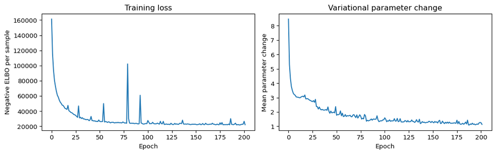

```python
fig, axes = plt.subplots(1, 2, figsize=(11, 3.5))
axes[0].plot(np.array(factor_model.loss_history[1:]) / n_train)
axes[0].set(xlabel="Epoch", ylabel="Negative ELBO per sample", title="Training loss")
axes[1].plot(factor_model.var_param_convergence_history[1:])
axes[1].set(xlabel="Epoch", ylabel="Mean parameter change", title="Variational parameter change")
plt.tight_layout()
save_fig(fig, "training_loss.png")
plt.show()
```

### 3b. Is training long enough?

`convergence_check.py` refits this model on the same split with fixed training lengths (the stopping rule switched off) and records the training loss, the test performance, and how much the fitted signal $\hat Z\hat\Lambda^\top$ changes between lengths. With the stopping rule alone the fit stopped near epoch 100, while the loss was still falling steeply (23% lower by epoch 200). After 200 the gains are small (about 9% more by epoch 1 600), so `min_epochs` is 200 above. Test R² hardly changes with training length, so the gap to the penalised regressions (section 7) is not a convergence problem; longer training mainly narrows the predictive intervals.

|  | epochs | final_loss_per_sample | test_r2 | coverage_95 | width_95 | active_factors | signal_change_vs_previous |
| --- | --- | --- | --- | --- | --- | --- | --- |
| 0 | 100 | 29800.907 | 0.430 | 0.915 | 3.220 | 11 | NaN |
| 1 | 200 | 23003.994 | 0.439 | 0.906 | 3.076 | 11 | 0.027 |
| 2 | 400 | 22331.924 | 0.435 | 0.906 | 2.963 | 11 | 0.014 |
| 3 | 800 | 21309.125 | 0.441 | 0.915 | 2.861 | 12 | 0.012 |
| 4 | 1600 | 20868.779 | 0.421 | 0.906 | 2.838 | 12 | 0.016 |

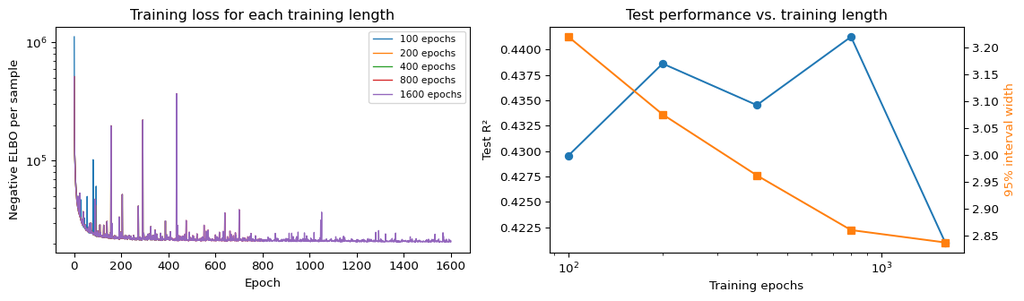

```python
conv_path = os.path.join(RESULTS, "convergence_check.csv")
if os.path.exists(conv_path):
    conv = pd.read_csv(conv_path)
    display(conv[["epochs", "final_loss_per_sample", "test_r2", "coverage_95", "width_95",
                  "active_factors", "signal_change_vs_previous"]].round(3))
    fig, axes = plt.subplots(1, 2, figsize=(12, 3.6))
    for e in conv["epochs"]:
        curve = pd.read_csv(os.path.join(RESULTS, f"convergence_loss_{e}.csv"))
        axes[0].plot(curve["epoch"], curve["loss_per_sample"], label=f"{e} epochs", lw=1)
    axes[0].set(xlabel="Epoch", ylabel="Negative ELBO per sample", yscale="log",
                title="Training loss for each training length")
    axes[0].legend(fontsize=8)
    axes[1].plot(conv["epochs"], conv["test_r2"], marker="o", label="test R²")
    axes[1].set(xscale="log", xlabel="Training epochs", ylabel="Test R²",
                title="Test performance vs. training length")
    ax2 = axes[1].twinx()
    ax2.plot(conv["epochs"], conv["width_95"], marker="s", color="tab:orange", label="95% interval width")
    ax2.set_ylabel("95% interval width", color="tab:orange")
    plt.tight_layout()
    save_fig(fig, "convergence_check.png")
    plt.show()
else:
    print("Run convergence_check.py to produce this section.")
```

## 4. Prediction on the test samples

**Local inference.** For the test samples the global parameters are frozen and only their factor scores are inferred, from their expression and methylation alone; their TMB is never used.

```python
factor_model, test_handler, local_state = train_model_locally(
    factor_model, TRAIN_CONFIG, test_subset, model_out_filename=SAVE_STEM,
    model_type="shared", verbose=VERBOSE,
)
print(f"Local inference: {factor_model.local_epochs} epochs, {local_state['inference_time']:.0f}s")
```

```
Local inference: 202 epochs, 40s
```

**Metrics** (log(1 + TMB) scale): MSE; $R^2 = 1 - \text{SSE}/\text{SST}$ on the test samples (0 = no better than the mean, 1 = perfect); and the coverage and mean width of the 95% posterior predictive intervals (good intervals cover about 95% while staying narrow).

```python
post_test = test_handler.predict(dp["test_X_l_list_clean"], N_POSTERIOR_SAMPLES, [Sites.y_pred])
pred = summarise_post_samples(post_test[Sites.y_pred].squeeze().cpu() * y_sd + y_mean)
y_true = data["y_test"].reshape(-1)
resid = pred["mean"] - y_true
test_metrics = pd.Series({
    "MSE":             float((resid ** 2).mean()),
    "R2":              float(1 - (resid ** 2).sum() / ((y_true - y_true.mean()) ** 2).sum()),
    "coverage_95":     float(((y_true >= pred["q2.5"]) & (y_true <= pred["q97.5"])).float().mean()),
    "width_95":        float((pred["q97.5"] - pred["q2.5"]).mean()),
    "global_epochs":   factor_model.total_epochs,
    "global_runtime_s": global_state["inference_time"],
    "local_runtime_s": local_state["inference_time"],
}, name="value")
save_table(test_metrics.round(4).to_frame(), "test_metrics.csv")
```

|  | value |
| --- | --- |
| MSE | 0.7806 |
| R2 | 0.4378 |
| coverage_95 | 0.9151 |
| width_95 | 2.9625 |
| global_epochs | 203.0000 |
| global_runtime_s | 129.9913 |
| local_runtime_s | 39.8754 |

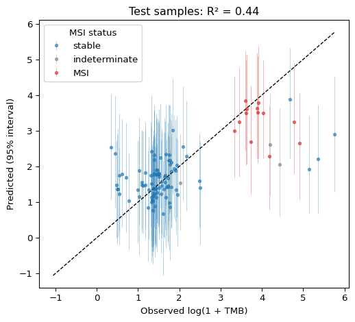

```python
predictions = pd.DataFrame({
    "sample_id": data["sample_ids_test"], "y_true": y_true.numpy(),
    "y_pred": pred["mean"].numpy(), "q2.5": pred["q2.5"].numpy(), "q97.5": pred["q97.5"].numpy(),
}).set_index("sample_id").join(clin[["MSI_STATUS", "SUBTYPE"]])
save_table(predictions, "test_predictions.csv")

fig, ax = plt.subplots(figsize=(5.5, 5))
colours = {"stable": "tab:blue", "indeterminate": "tab:gray", "MSI": "tab:red"}
for status, grp in predictions.groupby("MSI_STATUS", observed=True):
    ax.errorbar(grp["y_true"], grp["y_pred"],
                yerr=[grp["y_pred"] - grp["q2.5"], grp["q97.5"] - grp["y_pred"]],
                fmt="o", ms=3, elinewidth=0.4, alpha=0.6, color=colours.get(status, "black"),
                label=status)
lims = [predictions[["y_true", "q2.5"]].min().min(), predictions[["y_true", "q97.5"]].max().max()]
ax.plot(lims, lims, "k--", lw=1)
ax.set(xlabel="Observed log(1 + TMB)", ylabel="Predicted (95% interval)",
       title=f"Test samples: R² = {test_metrics['R2']:.2f}")
ax.legend(title="MSI status")
plt.tight_layout()
save_fig(fig, "test_predictions.png")
plt.show()
```

## 5. How strong is the TMB signal in the data?

For a direction in factor space, its **strength** is its signal summed over all $P$ features relative to the noise (eigenvalues of $M = \sum_l \Lambda^{(l)\top}\Psi^{(l)-1}\Lambda^{(l)}$, measured on the scale of the fitted signal). A direction stronger than $\sqrt{P/n}$ stands out in the data even without the outcome, so unsupervised methods can find it; a strength above about 1 is needed to infer a new sample’s score from its features. The red line is the strength along the direction the model uses to predict TMB. (This estimate was checked against simulations with known truth, where it was within about 30%.)

```python
Lambda_fit = [pyro.param(Params.loc_Lambda_l.format(l=l)).detach().squeeze() for l in range(L)]
beta_fit = pyro.param(Params.loc_beta).detach().reshape(-1)
Z_second_moment = Z_loc.T @ Z_loc / n_train + torch.diag((Z_scale ** 2).mean(0))
strength = factor_strength(Lambda_fit, psi_hat, beta_fit, Z_second_moment=Z_second_moment)
P = sum(x.shape[1] for x in dp["train_X_l_list_clean"])
threshold = np.sqrt(P / n_train)

save_table(pd.Series({
    "outcome_direction_strength": strength["outcome_strength"],
    "detection_threshold_sqrt_P_over_n": threshold,
    "ratio": strength["outcome_strength"] / threshold,
    "directions_above_threshold": int((strength["eigenvalues"] > threshold).sum()),
}, name="value").round(2).to_frame(), "factor_strength_summary.csv")
```

|  | value |
| --- | --- |
| outcome_direction_strength | 393.26 |
| detection_threshold_sqrt_P_over_n | 2.66 |
| ratio | 147.79 |
| directions_above_threshold | 20.00 |

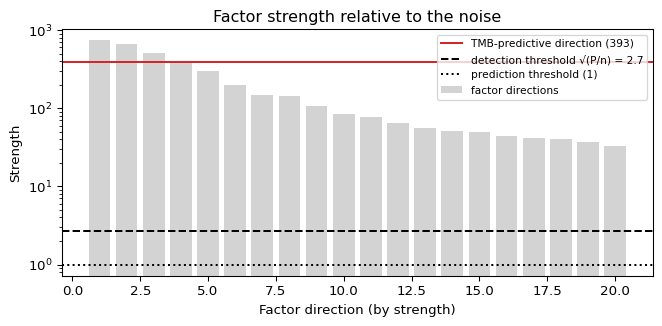

```python
fig, ax = plt.subplots(figsize=(7, 3.5))
ax.bar(np.arange(1, K + 1), strength["eigenvalues"], color="lightgray", label="factor directions")
ax.axhline(strength["outcome_strength"], color="tab:red",
           label=f"TMB-predictive direction ({strength['outcome_strength']:.0f})")
ax.axhline(threshold, color="black", ls="--", label=f"detection threshold √(P/n) = {threshold:.1f}")
ax.axhline(1, color="black", ls=":", label="prediction threshold (1)")
ax.set(yscale="log", xlabel="Factor direction (by strength)", ylabel="Strength",
       title="Factor strength relative to the noise")
ax.legend(fontsize=8)
plt.tight_layout()
save_fig(fig, "factor_strength.png")
plt.show()
```

## 6. Factor interpretation

Interpretation uses the posterior means of the training samples’ scores $\hat Z$, the loadings $\hat\Lambda^{(l)}$ and the outcome effects $\hat{\boldsymbol\beta}$. Factors are rotated with multiview varimax (one rotation for both views, each view weighted equally) so each factor loads strongly on a few genes; predictions are unchanged by the rotation. Factor numbers below refer to the rotated factors.

```python
sites = [Sites.Z, Sites.beta] + [Sites.Lambda_l.format(l=l) for l in range(L)]
post_train = train_handler.predict(dp["train_X_l_list_clean"], N_POSTERIOR_SAMPLES, sites)
post_train = {k: v.cpu() for k, v in post_train.items()}
Z_hat      = post_train[Sites.Z].mean(0)
Lambda_hat = [post_train[Sites.Lambda_l.format(l=l)].mean(0).squeeze() for l in range(L)]
beta_hat   = post_train[Sites.beta].mean(0).squeeze()
y_train    = dp["train_y_clean"].squeeze()
```

### Factor summary

Each row is a rotated factor, sorted by the share of the data it explains. `PVE(data)` is the share of all the data’s variance; `β` and its 95% interval give the factor’s effect on standardised log(1 + TMB) (`*` = interval excludes zero); `β-R²(y)` is the share of the outcome’s variance the factor explains. Column definitions are in `sim/python_integration.qmd`.

```
======================================================================================================================
  Factor Summary — Varimax-rotated
======================================================================================================================
  Total model R²          : 0.5186
  Total signal / TSS      : 0.4174
  R² [Expression          ]  : 0.5550
  R² [TSS200 methylation  ]  : 0.4457
  Total outcome R²        : 0.5202

  Per-factor breakdown (sorted by data PVE):
  Factor         ESS  PVE(factor)  PVE(model)  PVE(data)  R²(MOFA)         β    β-PVE              95% CI      β-R²(y)
  --------------------------------------------------------------------------------------------------------------------
       2    74307.06       0.1402      0.1128     0.0585    0.0709   -0.0342   0.0018  [-0.1381, 0.0665]       0.0007
       3    57861.23       0.1092      0.0879     0.0456    0.0561    0.6022   0.4896  [ 0.4991, 0.7202]  *    0.1973
       1    55850.56       0.1054      0.0848     0.0440    0.0605   -0.3416   0.1557  [-0.4457,-0.2317]  *    0.0627
       4    53174.74       0.1003      0.0807     0.0419    0.0539   -0.0448   0.0027  [-0.1562, 0.0575]       0.0011
       7    34068.43       0.0643      0.0517     0.0268    0.0407   -0.1281   0.0196  [-0.2402,-0.0192]  *    0.0079
       6    32081.60       0.0605      0.0487     0.0253    0.0307    0.0429   0.0020  [-0.0681, 0.1681]       0.0008
       9    27750.09       0.0524      0.0421     0.0219    0.0316    0.1365   0.0197  [ 0.0165, 0.2494]  *    0.0080
       8    25211.65       0.0476      0.0383     0.0199    0.0214   -0.0201   0.0005  [-0.1253, 0.0787]       0.0002
       5    22334.36       0.0421      0.0339     0.0176    0.0248   -0.2208   0.0453  [-0.3547,-0.0908]  *    0.0183
      10    21996.57       0.0415      0.0334     0.0173    0.0259    0.2160   0.0436  [ 0.0813, 0.3558]  *    0.0176
      11    21703.31       0.0409      0.0330     0.0171    0.0232    0.1360   0.0169  [-0.0054, 0.2589]       0.0068
      12    14591.26       0.0275      0.0222     0.0115    0.0181    0.3261   0.0779  [ 0.1888, 0.4791]  *    0.0314
      17    12921.89       0.0244      0.0196     0.0102    0.0144   -0.0589   0.0025  [-0.2084, 0.0738]       0.0010
      14    12340.01       0.0233      0.0187     0.0097    0.0147    0.0573   0.0022  [-0.0997, 0.1989]       0.0009
      19    11714.07       0.0221      0.0178     0.0092    0.0143   -0.1222   0.0098  [-0.2577, 0.0214]       0.0040
      16    11060.11       0.0209      0.0168     0.0087    0.0134   -0.0740   0.0034  [-0.2286, 0.0755]       0.0014
      18    10849.20       0.0205      0.0165     0.0085    0.0138   -0.2845   0.0499  [-0.4292,-0.1483]  *    0.0201
      15    10662.40       0.0201      0.0162     0.0084    0.0128   -0.0712   0.0031  [-0.2173, 0.0675]       0.0012
      13     9778.52       0.0184      0.0148     0.0077    0.0118    0.2091   0.0256  [ 0.0598, 0.3466]  *    0.0103
      20     9775.29       0.0184      0.0148     0.0077    0.0126   -0.2187   0.0283  [-0.3760,-0.0765]  *    0.0114

  Cumulative PVE (data): [0.059  0.104  0.148  0.190  0.217  0.242  0.264  0.284  0.301  0.319  0.336  0.347  0.357  0.367  0.376  0.385  0.394  0.402  0.410  0.417]
  * 95% CI excludes zero

  Per-factor PVE by view  [ESS_kl / TSS_l]:
  Factor            Expression    TSS200 methylation
  ----------------------------------------------------
       2                0.0860                0.0036
       3                0.0163                0.1041
       1                0.0228                0.0865
       4                0.0611                0.0033
       7                0.0382                0.0041
       6                0.0055                0.0649
       9                0.0309                0.0037
       8                0.0027                0.0542
       5                0.0248                0.0031
      10                0.0223                0.0074
      11                0.0232                0.0049
      12                0.0136                0.0073
      17                0.0129                0.0047
      14                0.0131                0.0030
      19                0.0132                0.0012
      16                0.0113                0.0035
      18                0.0116                0.0025
      15                0.0114                0.0023
      13                0.0103                0.0025
      20                0.0074                0.0082
======================================================================================================================
```

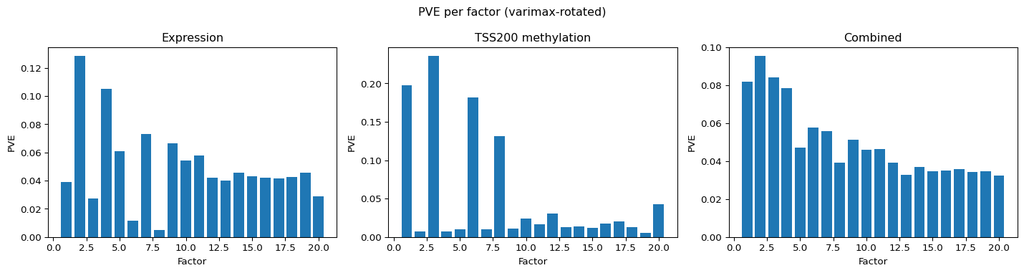

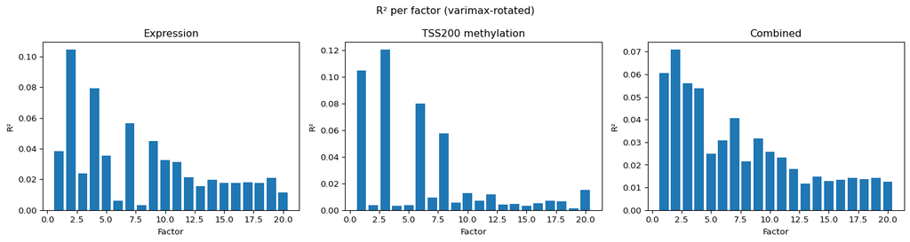

```
13 factors explain more than 1% of the data: [2, 3, 1, 4, 7, 6, 9, 8, 5, 10, 11, 12, 17]
Factors ranked by outcome variance explained: [3, 1, 12, 18, 5, 10]
```

```python
factor_summary = summarize_factors(
    X_list=dp["train_X_l_list_clean"], Z=Z_hat, Lambda_list=Lambda_hat,
    beta=beta_hat, y=y_train, beta_samples=post_train[Sites.beta],
    view_names=VIEW_NAMES, plot=True, verbose=True, show="post",
)
per_factor = factor_summary["post"]["per_factor"].copy()
save_table(per_factor.round(4), "factor_summary.csv", index=False)
active = per_factor.loc[per_factor["pve_data"] > 0.01, "factor"].tolist()     # 1-based
by_outcome = per_factor.sort_values("beta_r2_y", ascending=False)["factor"].tolist()
print(f"{len(active)} factors explain more than 1% of the data:", active)
print("Factors ranked by outcome variance explained:", by_outcome[:6])
```

### Loadings

Rotated loadings for each view: rows are genes, ordered by the factor they load on most strongly; each factor’s genes form a block. Saved as `loadings.png`.

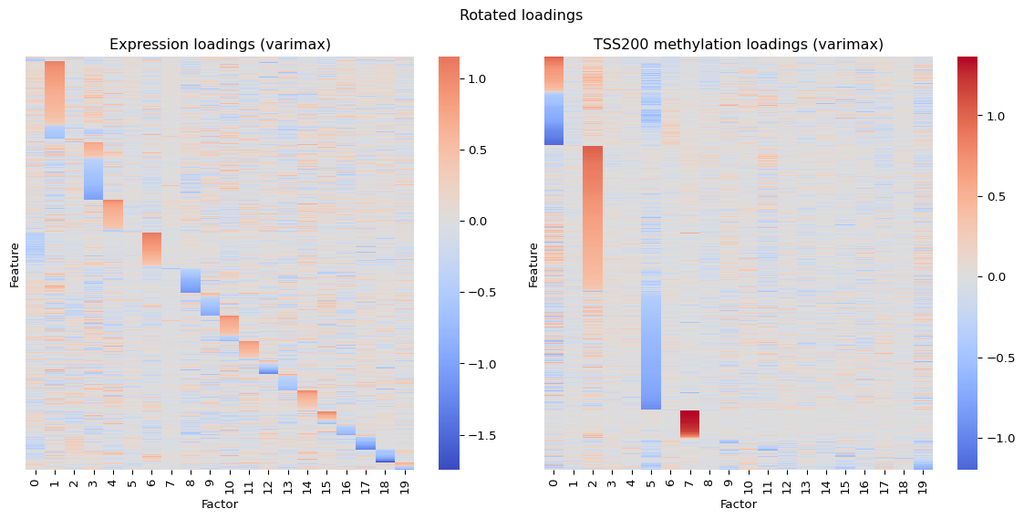

```python
_ = plot_factor_loadings(Lambda_hat, view_names=VIEW_NAMES, rotate=True, sort_features=True,
                         title="Rotated loadings", save_path=os.path.join(FIGURES, "loadings.png"))
```

### Genes within each factor

For the factors most associated with TMB, the genes with the largest rotated loadings in either view, coloured by view. A factor that combines expression and methylation genes describes a coordinated expression–methylation programme. Saved as `factor_genes.png`; the full lists are in `top_genes_<view>.csv`.

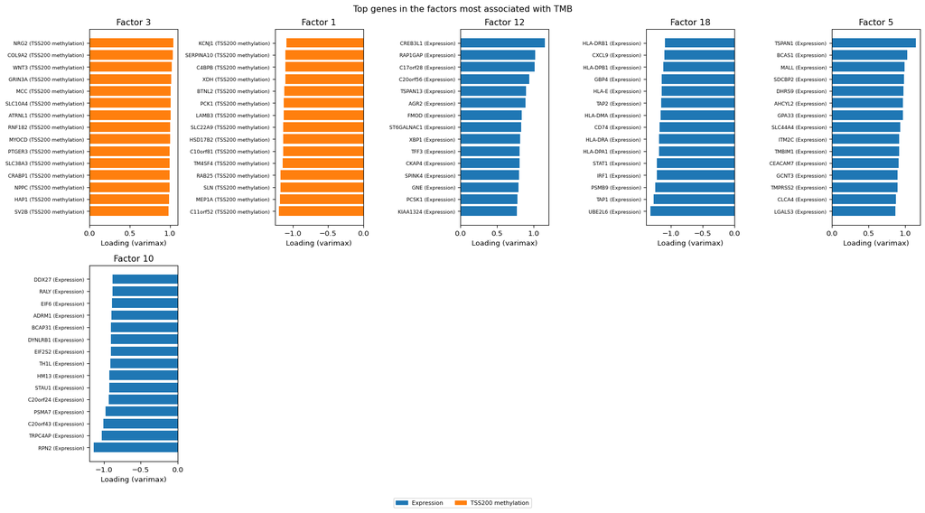

```python
top_outcome = [k - 1 for k in by_outcome[:6]]
factor_genes = plot_factor_features(
    Lambda_hat, factors=top_outcome, n_top_features=15, view_names=VIEW_NAMES,
    feature_names_list=feature_names, rotate=True,
    title="Top genes in the factors most associated with TMB",
    save_path=os.path.join(FIGURES, "factor_genes.png"),
)
save_table(factor_genes, "factor_genes_top_outcome_factors.csv", index=False)

for name, tbl in zip(VIEW_NAMES, tabulate_top_features(Lambda_hat, feature_names_list=feature_names,
                                                        n_top_factors=len(active), n_top_features=20,
                                                        rotate=True)):
    save_table(tbl, f"top_genes_{name.split()[0].lower()}.csv")
```

### Factor scores and TMB

Training samples ordered by each factor’s score, with their log(1 + TMB). A trend means the factor tracks TMB. Saved as `scores_vs_tmb.png`.

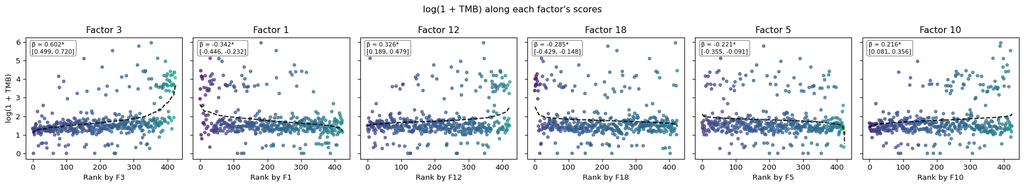

```python
plot_factor_outcome(
    factor_summary["Z_rot"], data["y"].numpy(), top_factors=top_outcome, n_factors_show=6,
    outcome_label="log(1 + TMB)", title="log(1 + TMB) along each factor's scores",
    factor_summary=factor_summary, save_path=os.path.join(FIGURES, "scores_vs_tmb.png"),
)
```

### What the factors capture: association with clinical variables

To see what each active factor represents, its (rotated) training scores are compared with clinical variables the model never saw: Spearman correlation for numeric variables, and the share of score variance explained by group membership ($\eta^2$ from one-way ANOVA) for categorical ones. A factor strongly tied to tissue source site, for example, would point to a batch effect rather than biology. Saved as `clinical_associations.csv` and `.png`.

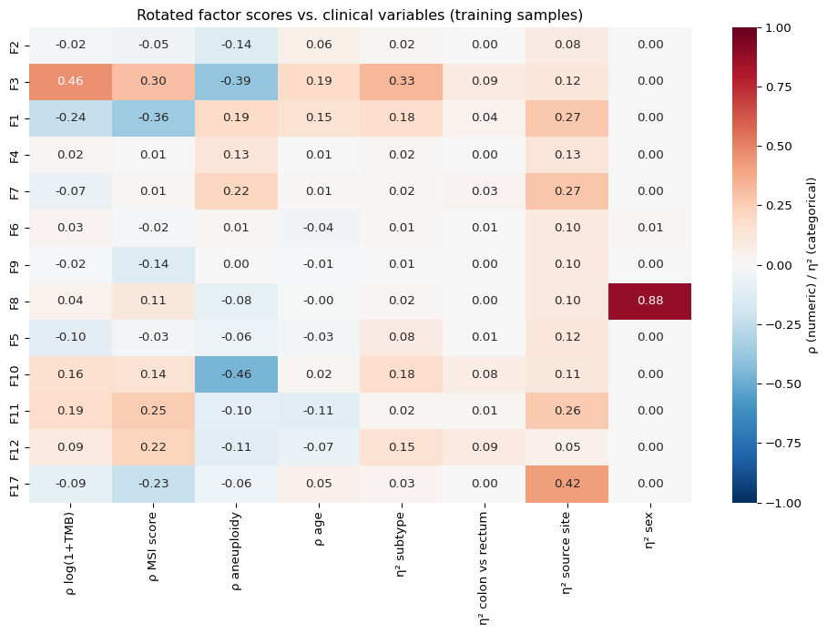

```python
scores = pd.DataFrame(factor_summary["Z_rot"], index=data["sample_ids_train"],
                      columns=[f"F{k}" for k in range(1, K + 1)])[[f"F{k}" for k in active]]
clin_train = clin.loc[data["sample_ids_train"]]

def eta_squared(score, groups):
    ok = groups.notna()
    s, g = score[ok], groups[ok]
    return float(((s.groupby(g).transform("mean") - s.mean()) ** 2).sum() / ((s - s.mean()) ** 2).sum())

numeric = {"log(1+TMB)": clin_train["log1p_TMB"], "MSI score": clin_train["MSI_SCORE_MANTIS"],
           "aneuploidy": clin_train["ANEUPLOIDY_SCORE"], "age": clin_train["AGE"]}
categorical = {"subtype": clin_train["SUBTYPE"], "colon vs rectum": clin_train["SITE"],
               "source site": clin_train["TISSUE_SOURCE_SITE_CODE"], "sex": clin_train["SEX"]}
assoc = pd.DataFrame({
    **{f"ρ {k}": [spearmanr(scores[f], v, nan_policy="omit")[0] for f in scores] for k, v in numeric.items()},
    **{f"η² {k}": [eta_squared(scores[f], v) for f in scores] for k, v in categorical.items()},
}, index=scores.columns)
save_table(assoc.round(3), "clinical_associations.csv")

fig, ax = plt.subplots(figsize=(10, 0.45 * len(assoc) + 1.5))
sns.heatmap(assoc, annot=True, fmt=".2f", cmap="RdBu_r", center=0, vmin=-1, vmax=1,
            cbar_kws={"label": "ρ (numeric) / η² (categorical)"}, ax=ax)
ax.set(title="Rotated factor scores vs. clinical variables (training samples)")
plt.tight_layout()
save_fig(fig, "clinical_associations.png")
plt.show()
```

The factor most associated with TMB, by molecular subtype and MSI status (saved as `top_factor_by_subtype.png`):

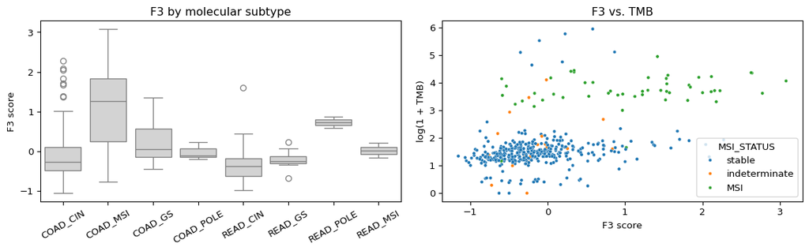

```python
f_top = f"F{by_outcome[0]}"
plot_df = clin_train.assign(score=scores[f_top] if f_top in scores else factor_summary["Z_rot"][:, by_outcome[0] - 1])
fig, axes = plt.subplots(1, 2, figsize=(12, 3.8))
sns.boxplot(data=plot_df, x="SUBTYPE", y="score", ax=axes[0], color="lightgray")
axes[0].set(xlabel="", ylabel=f"{f_top} score", title=f"{f_top} by molecular subtype")
axes[0].tick_params(axis="x", rotation=30)
sns.scatterplot(data=plot_df, x="score", y="log1p_TMB", hue="MSI_STATUS", s=12, ax=axes[1])
axes[1].set(xlabel=f"{f_top} score", ylabel="log(1 + TMB)", title=f"{f_top} vs. TMB")
plt.tight_layout()
save_fig(fig, "top_factor_by_subtype.png")
plt.show()
```

## 7. Comparison with other methods

`compare_methods.py` fits every method to the same five random 80/20 splits (split 1 is the split used above), with the same genes and standardisation:

| Method | Description |
| --- | --- |
| `shared` | this model |
| `mofa` | MOFA2 (unsupervised, $K = 20$) + OLS of TMB on its factors |
| `pca_ols` | PCA of the stacked views ($K = 20$) + OLS |
| `ridge` | ridge regression on all genes, penalty by 5-fold CV |
| `elastic_net` | elastic net on all genes, penalty and mix by 5-fold CV |
| `mean` | the training mean (R² ≈ 0 reference) |

Re-run with `python analysis/tcga_coadread/compare_methods.py` (about 40 minutes; it resumes where it stopped).

```python
comp_path = os.path.join(RESULTS, "method_comparison_splits.csv")
if os.path.exists(comp_path):
    comp = pd.read_csv(comp_path)
    order = ["shared", "mofa", "pca_ols", "ridge", "elastic_net", "mean"]
    summary = (comp.groupby("method")[["r2", "mse", "coverage_95", "width_95", "test_rse", "runtime"]]
                   .agg(["mean", "std"]).reindex([m for m in order if m in set(comp["method"])]))
    print(f"{comp['seed'].nunique()} splits")
    display(save_table(summary.round(3), "method_comparison_summary.csv"))
else:
    comp = None
    print("No comparison results yet: run compare_methods.py")
```

```
5 splits
```

| method | r2 mean | r2 std | mse mean | mse std | coverage_95 mean | coverage_95 std | width_95 mean | width_95 std | test_rse mean | test_rse std | runtime mean | runtime std |
| --- | --- | --- | --- | --- | --- | --- | --- | --- | --- | --- | --- | --- |
| shared | 0.441 | 0.048 | 0.597 | 0.130 | 0.932 | 0.012 | 3.064 | 0.111 | 0.548 | 0.016 | 251.207 | 38.570 |
| mofa | 0.433 | 0.071 | 0.601 | 0.121 | 0.930 | 0.016 | 2.971 | 0.095 | 0.545 | 0.015 | 83.595 | 29.948 |
| pca_ols | 0.451 | 0.051 | 0.584 | 0.125 | NaN | NaN | NaN | NaN | 0.542 | 0.016 | 0.052 | 0.011 |
| ridge | 0.633 | 0.066 | 0.383 | 0.053 | NaN | NaN | NaN | NaN | NaN | NaN | 0.665 | 0.032 |
| elastic_net | 0.594 | 0.056 | 0.430 | 0.085 | NaN | NaN | NaN | NaN | NaN | NaN | 3.075 | 0.273 |
| mean | -0.017 | 0.012 | 1.098 | 0.284 | NaN | NaN | NaN | NaN | NaN | NaN | 0.000 | 0.000 |

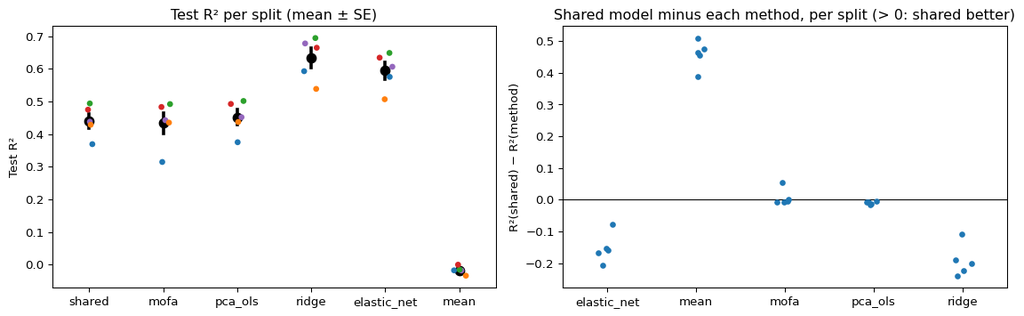

```python
if comp is not None:
    fig, axes = plt.subplots(1, 2, figsize=(12, 3.8))
    sns.pointplot(data=comp, x="method", y="r2", order=[m for m in order if m in set(comp["method"])],
                  errorbar="se", join=False, color="black", ax=axes[0])
    sns.stripplot(data=comp, x="method", y="r2", order=[m for m in order if m in set(comp["method"])],
                  hue="seed", palette="tab10", size=5, ax=axes[0], legend=False)
    axes[0].set(xlabel="", ylabel="Test R²", title="Test R² per split (mean ± SE)")
    paired = comp.pivot(index="seed", columns="method", values="r2")
    if "shared" in paired:
        diffs = paired.drop(columns="shared").sub(paired["shared"], axis=0).mul(-1)
        sns.stripplot(data=diffs.melt(var_name="method", value_name="d"), x="method", y="d", ax=axes[1])
        axes[1].axhline(0, color="black", lw=0.8)
        axes[1].set(xlabel="", ylabel="R²(shared) − R²(method)",
                    title="Shared model minus each method, per split (> 0: shared better)")
    plt.tight_layout()
    save_fig(fig, "method_comparison.png")
    plt.show()
```

### 7b. Comparing the factors

Since the factor model’s value here is interpretation rather than prediction, this section compares the **factors** of the three factor methods — the shared model, MOFA and PCA, each with 20 factors — fitted in `compare_methods.py`. Every method’s loadings get the same post-processing (multiview varimax rotation, scores rotated with them), so differences come from the fits. Unless stated, results are for split 1 (the split used above); stability uses all five splits.

| Measure | Question | Better |
| --- | --- | --- |
| Outcome concentration | Is TMB carried by one or two factors, or spread over many? Share of the factors’ outcome R² in the top factor, and number of factors needed for 80% of it | concentrated: easier to interpret |
| Clinical alignment | For each clinical variable, the strongest association among a method’s active factors (Spearman $\|\rho\|$ or $\eta^2$) | higher, except source site (a batch proxy) |
| Multiview coupling | Number of active factors with at least 20% of their loading energy in each view | depends on the biology; shows whether factors combine views |
| Loading concentration | Share of a factor’s loading energy in its top 5% of genes, averaged over active factors | higher: fewer genes to read |
| Stability | For each active factor, the best correlation of its loadings with a factor refitted on another split (genes matched by name), averaged | higher: reproducible |

“Active” factors explain more than 1% of the data’s variance. Factor numbers in this section come from rotating each method’s saved loadings and need not match the numbering of section 6.

```python
from factor_interpretation import _rotate_loadings

FACTOR_METHODS = ["shared", "mofa", "pca_ols"]
METHOD_LABEL = {"shared": "shared model", "mofa": "MOFA", "pca_ols": "PCA"}
SEEDS = sorted(int(d.replace("seed", "")) for d in os.listdir(os.path.join(RESULTS, "splits")))
split_dir = lambda seed: os.path.join(RESULTS, "splits", f"seed{seed}")

def load_factors(method, seed):
    """Rotated factors of one method on one split, plus genes and training samples."""
    f = np.load(os.path.join(split_dir(seed), f"{method}_factors.npz"))
    loadings = [f[f"loadings_view{l}"] for l in range(L)]
    rotated, R = _rotate_loadings(loadings)
    Z = f["Z_train"] @ R
    beta = R.T @ f["beta"]
    genes = [open(os.path.join(split_dir(seed), f"genes_view{l}.txt")).read().split("\n") for l in range(L)]
    samples = open(os.path.join(split_dir(seed), "train_samples.txt")).read().split("\n")
    n, P_ = Z.shape[0], sum(len(g) for g in genes)
    energy = np.sum(Z ** 2, 0) * sum(np.sum(Lv ** 2, 0) for Lv in rotated)
    return {"loadings": rotated, "Z": Z, "beta": beta, "genes": genes, "samples": samples,
            "active": np.where(energy / (n * P_) > 0.01)[0]}

have_factors = all(os.path.exists(os.path.join(split_dir(sd), f"{m}_factors.npz"))
                   for m in FACTOR_METHODS for sd in SEEDS)
print("Factor outputs for all methods and splits:", have_factors)
```

```
Factor outputs for all methods and splits: True
```

```python
def factor_measures(fac, y_train, clin_train):
    Z, act, loadings = fac["Z"], fac["active"], fac["loadings"]
    # beta is on the standardised outcome scale, so divide by that scale's sum of squares
    y_std = (y_train - y_train.mean()) / y_train.std(ddof=1)
    r2 = fac["beta"] ** 2 * np.sum(Z ** 2, 0) / np.sum(y_std ** 2)    # outcome R² per factor
    r2s = np.sort(r2)[::-1]
    view_energy = np.array([np.sum(Lv ** 2, 0) for Lv in loadings])   # (L, K)
    view_share = view_energy / view_energy.sum(0)
    stacked = np.vstack(loadings)
    top = max(1, int(0.05 * stacked.shape[0]))
    conc = np.sort(stacked ** 2, 0)[::-1][:top].sum(0) / (stacked ** 2).sum(0)
    out = {
        "active factors": len(act),
        "outcome R² (all factors)": r2.sum(),
        "top factor share of outcome R²": r2s[0] / r2s.sum(),
        "factors for 80% of outcome R²": int(np.searchsorted(np.cumsum(r2s) / r2s.sum(), 0.8) + 1),
        "factors using both views": int(np.sum((view_share[:, act] >= 0.2).all(0))),
        "loading concentration (top 5% genes)": conc[act].mean(),
    }
    scores = pd.DataFrame(Z[:, act], index=fac["samples"])
    for name, col in [("MSI score", "MSI_SCORE_MANTIS"), ("aneuploidy", "ANEUPLOIDY_SCORE"), ("age", "AGE")]:
        out[f"max |ρ| {name}"] = max(abs(spearmanr(scores[k], clin_train[col], nan_policy="omit")[0]) for k in scores)
    for name, col in [("subtype", "SUBTYPE"), ("colon vs rectum", "SITE"), ("source site (batch)", "TISSUE_SOURCE_SITE_CODE")]:
        out[f"max η² {name}"] = max(eta_squared(scores[k], clin_train[col]) for k in scores)
    return out

if have_factors:
    rows = []
    for seed in SEEDS:
        for m in FACTOR_METHODS:
            fac = load_factors(m, seed)
            ct = clin.loc[fac["samples"]]
            y_tr = ct["log1p_TMB"].values
            rows.append({"seed": seed, "method": METHOD_LABEL[m], **factor_measures(fac, y_tr, ct)})
    factor_comp = pd.DataFrame(rows)
    save_table(factor_comp.round(4), "factor_comparison_per_split.csv", index=False)
    display(save_table(factor_comp.drop(columns="seed").groupby("method").agg(["mean", "std"]).T.round(3),
                       "factor_comparison_summary.csv"))
```

|  | method | MOFA | PCA | shared model |
| --- | --- | --- | --- | --- |
| active factors | mean | 14.400 | 20.000 | 13.400 |
|  | std | 0.548 | 0.000 | 1.140 |
| outcome R² (all factors) | mean | 0.378 | 0.380 | 0.399 |
|  | std | 0.020 | 0.056 | 0.006 |
| top factor share of outcome R² | mean | 0.341 | 0.500 | 0.476 |
|  | std | 0.059 | 0.175 | 0.045 |
| factors for 80% of outcome R² | mean | 5.400 | 4.800 | 4.400 |
|  | std | 0.548 | 1.789 | 0.548 |
| factors using both views | mean | 1.800 | 3.200 | 2.600 |
|  | std | 0.447 | 0.837 | 0.548 |
| loading concentration (top 5% genes) | mean | 0.516 | 0.485 | 0.501 |
|  | std | 0.007 | 0.005 | 0.008 |
| max \|ρ\| MSI score | mean | 0.371 | 0.419 | 0.365 |
|  | std | 0.027 | 0.025 | 0.018 |
| max \|ρ\| aneuploidy | mean | 0.526 | 0.530 | 0.456 |
|  | std | 0.031 | 0.026 | 0.014 |
| max \|ρ\| age | mean | 0.231 | 0.268 | 0.227 |
|  | std | 0.021 | 0.041 | 0.025 |
| max η² subtype | mean | 0.318 | 0.462 | 0.344 |
|  | std | 0.050 | 0.077 | 0.036 |
| max η² colon vs rectum | mean | 0.098 | 0.143 | 0.092 |
|  | std | 0.017 | 0.033 | 0.010 |
| max η² source site (batch) | mean | 0.316 | 0.376 | 0.316 |
|  | std | 0.050 | 0.042 | 0.076 |

**Stability across splits.** Each split selects its genes on its own training samples, so loadings are compared on the genes two splits share. For each active factor of split 1, the best absolute correlation with any factor of the other split is recorded; the figure shows these over the four other splits.

| method | mean best \|corr\|, active factors | top outcome factor |
| --- | --- | --- |
| MOFA | 0.942 | 0.984 |
| PCA | 0.837 | 0.748 |
| shared model | 0.938 | 0.984 |

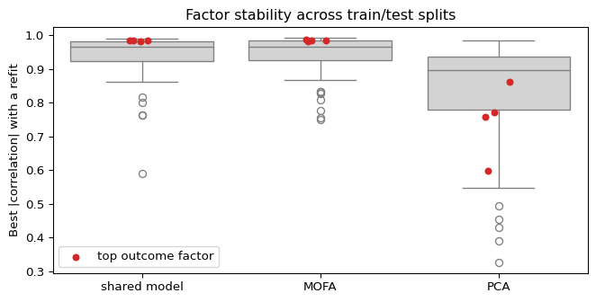

```python
def best_match(fac_a, fac_b, factors_a):
    """Best |correlation| of each of fac_a's factors with any of fac_b's, on shared genes."""
    va, vb = [], []
    for l in range(L):
        common = sorted(set(fac_a["genes"][l]) & set(fac_b["genes"][l]))
        ia = {g: i for i, g in enumerate(fac_a["genes"][l])}
        ib = {g: i for i, g in enumerate(fac_b["genes"][l])}
        va.append(fac_a["loadings"][l][[ia[g] for g in common]])
        vb.append(fac_b["loadings"][l][[ib[g] for g in common]])
    A, B = np.vstack(va), np.vstack(vb)
    A = (A - A.mean(0)) / A.std(0); B = (B - B.mean(0)) / B.std(0)
    C = np.abs(A.T @ B) / A.shape[0]
    return C[factors_a].max(1)

if have_factors:
    stab = []
    for m in FACTOR_METHODS:
        ref = load_factors(m, SPLIT_SEED)
        y_ref = clin.loc[ref["samples"], "log1p_TMB"].values
        r2_ref = ref["beta"] ** 2 * np.sum(ref["Z"] ** 2, 0)
        top_outcome_factor = int(np.argmax(r2_ref))
        for seed in [sd for sd in SEEDS if sd != SPLIT_SEED]:
            other = load_factors(m, seed)
            for k, c in zip(ref["active"], best_match(ref, other, ref["active"])):
                stab.append({"method": METHOD_LABEL[m], "seed": seed, "factor": k + 1, "best |corr|": c,
                             "top outcome factor": k == top_outcome_factor})
    stab = pd.DataFrame(stab)
    save_table(stab, "factor_stability.csv", index=False)
    display(stab.groupby("method").agg(**{
        "mean best |corr|, active factors": ("best |corr|", "mean"),
        "top outcome factor": ("best |corr|", lambda s: s[stab.loc[s.index, "top outcome factor"]].mean()),
    }).round(3))

    fig, ax = plt.subplots(figsize=(7, 3.6))
    sns.boxplot(data=stab, x="method", y="best |corr|", color="lightgray", ax=ax)
    sns.stripplot(data=stab[stab["top outcome factor"]], x="method", y="best |corr|",
                  color="tab:red", size=6, ax=ax, label="top outcome factor")
    handles, labels = ax.get_legend_handles_labels()
    ax.legend(handles[:1], labels[:1], loc="lower left")
    ax.set(xlabel="", ylabel="Best |correlation| with a refit",
           title="Factor stability across train/test splits")
    plt.tight_layout()
    save_fig(fig, "factor_stability.png")
    plt.show()
```

**Do the methods find the same factors?** Correlation of the training scores of the shared model’s active factors with each other method’s active factors (split 1, same samples). A row with a high value means that factor has a counterpart in the other method.

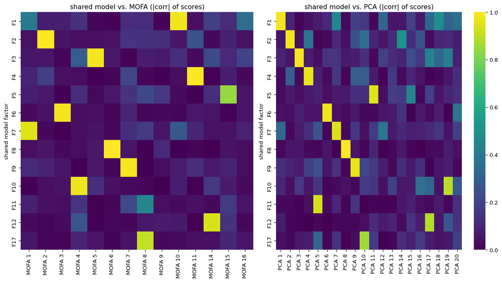

```python
if have_factors:
    ref = load_factors("shared", SPLIT_SEED)
    fig, axes = plt.subplots(1, 2, figsize=(13, 0.4 * len(ref["active"]) + 2))
    for ax, m in zip(axes, ["mofa", "pca_ols"]):
        other = load_factors(m, SPLIT_SEED)
        C = np.abs(np.corrcoef(ref["Z"][:, ref["active"]].T, other["Z"][:, other["active"]].T)
                   [:len(ref["active"]), len(ref["active"]):])
        sns.heatmap(pd.DataFrame(C, index=[f"F{k + 1}" for k in ref["active"]],
                                 columns=[f"{METHOD_LABEL[m]} {k + 1}" for k in other["active"]]),
                    vmin=0, vmax=1, cmap="viridis", ax=ax, cbar=ax is axes[-1])
        ax.set(title=f"shared model vs. {METHOD_LABEL[m]} (|corr| of scores)", ylabel="shared model factor")
    plt.tight_layout()
    save_fig(fig, "factor_correspondence.png")
    plt.show()
```

### 7c. Do the methods find the same factors?

Stability (above) compares a method with itself. Here the shared model’s factors are compared with MOFA’s and PCA’s on the same training samples, in three ways that do not depend on how factors happen to be rotated or ordered:

- **Subspaces:** canonical correlations between the spaces spanned by each method’s active training scores. Values near 1 mean the same variation is captured, however it is divided into factors.
- **Individual factors:** for each shared-model factor (after the same varimax rotation for every method), its best absolute correlation with a factor of the other method.
- **The outcome direction:** correlation of the methods’ fitted outcome predictions $\hat Z\hat{\boldsymbol\beta}$ on the training samples, and of their test predictions.

```python
def cancor(A, B):
    """Canonical correlations between the column spaces of A and B."""
    Qa, _ = np.linalg.qr(A - A.mean(0)); Qb, _ = np.linalg.qr(B - B.mean(0))
    return np.linalg.svd(Qa.T @ Qb, compute_uv=False)

if have_factors:
    rows = []
    for seed in SEEDS:
        sh = load_factors("shared", seed)
        for m in ["mofa", "pca_ols"]:
            ot = load_factors(m, seed)
            cc = cancor(sh["Z"][:, sh["active"]], ot["Z"][:, ot["active"]])
            C = np.abs(np.corrcoef(sh["Z"][:, sh["active"]].T, ot["Z"][:, ot["active"]].T)
                       [:len(sh["active"]), len(sh["active"]):])
            rows.append({
                "seed": seed, "compared with": METHOD_LABEL[m],
                "active factors (shared, other)": f"{len(sh['active'])}, {len(ot['active'])}",
                "canonical corr > 0.9": int((cc > 0.9).sum()),
                "median best factor |r|": np.median(C.max(1)),
                "factors matched > 0.9": int((C.max(1) > 0.9).sum()),
                "corr of fitted Zβ": np.corrcoef(sh["Z"] @ sh["beta"], ot["Z"] @ ot["beta"])[0, 1],
            })
    display(save_table(pd.DataFrame(rows).round(3), "factor_correspondence.csv", index=False))

    tp = pd.read_csv(os.path.join(RESULTS, "method_predictions.csv"))
    tp = tp[tp["seed"] == SPLIT_SEED].pivot(index="sample_id", columns="method", values="y_pred")
    print("Correlation of test predictions (split 1):")
    display(save_table(tp[["shared", "mofa", "pca_ols", "ridge", "elastic_net"]].corr().round(3),
                       "test_prediction_correlations.csv"))
```

|  | seed | compared with | active factors (shared, other) | canonical corr > 0.9 | median best factor \|r\| | factors matched > 0.9 | corr of fitted Zβ |
| --- | --- | --- | --- | --- | --- | --- | --- |
| 0 | 1 | MOFA | 12, 15 | 11 | 0.988 | 12 | 0.984 |
| 1 | 1 | PCA | 12, 20 | 12 | 0.956 | 8 | 0.995 |
| 2 | 2 | MOFA | 13, 14 | 12 | 0.981 | 13 | 0.994 |
| 3 | 2 | PCA | 13, 20 | 13 | 0.954 | 10 | 0.995 |
| 4 | 3 | MOFA | 14, 14 | 13 | 0.987 | 12 | 0.993 |
| 5 | 3 | PCA | 14, 20 | 14 | 0.930 | 10 | 0.992 |
| 6 | 4 | MOFA | 15, 15 | 14 | 0.976 | 15 | 0.994 |
| 7 | 4 | PCA | 15, 20 | 15 | 0.927 | 12 | 0.993 |
| 8 | 42 | MOFA | 13, 14 | 11 | 0.977 | 11 | 0.991 |
| 9 | 42 | PCA | 13, 20 | 13 | 0.963 | 10 | 0.992 |

```
Correlation of test predictions (split 1):
```

| method | shared | mofa | pca_ols | ridge | elastic_net |
| --- | --- | --- | --- | --- | --- |
| shared | 1.000 | 0.992 | 0.991 | 0.863 | 0.874 |
| mofa | 0.992 | 1.000 | 0.993 | 0.868 | 0.882 |
| pca_ols | 0.991 | 0.993 | 1.000 | 0.866 | 0.884 |
| ridge | 0.863 | 0.868 | 0.866 | 1.000 | 0.972 |
| elastic_net | 0.874 | 0.882 | 0.884 | 0.972 | 1.000 |

On this data the three factor methods recover essentially the same decomposition: the shared model’s factor space lies almost entirely within PCA’s and matches MOFA’s factor by factor, and their predictions correlate about 0.99. With `outcome_weight = 1` the outcome does not move the factors away from the dominant structure of the views.

### 7d. Where is the predictive signal that the factor models miss?

All factor methods reach the same R², below ridge. Two checks locate the gap: how PCA + OLS performs as the number of components grows, and whether the part of ridge’s test prediction lying outside the shared model’s factor space predicts the part of TMB outside it. (Computed on the five splits’ preprocessed matrices; saved as `pca_components_vs_r2.csv`.)

| seed | PCA+OLS K=5 | PCA+OLS K=10 | PCA+OLS K=20 | PCA+OLS K=40 | PCA+OLS K=80 | PCA+OLS K=160 | PCA+OLS K=300 | ridge | shared (K=20) | corr(ridge outside part, y outside part) |
| --- | --- | --- | --- | --- | --- | --- | --- | --- | --- | --- |
| 42 | 0.331 | 0.407 | 0.450 | 0.508 | 0.585 | 0.639 | 0.657 | 0.678 | 0.438 | 0.684 |
| 1 | 0.341 | 0.382 | 0.368 | 0.488 | 0.550 | 0.613 | 0.613 | 0.593 | 0.369 | 0.561 |
| 2 | 0.326 | 0.379 | 0.438 | 0.507 | 0.488 | 0.565 | 0.516 | 0.538 | 0.428 | 0.485 |
| 3 | 0.373 | 0.462 | 0.501 | 0.586 | 0.614 | 0.658 | 0.679 | 0.694 | 0.494 | 0.686 |
| 4 | 0.448 | 0.460 | 0.491 | 0.539 | 0.575 | 0.597 | 0.654 | 0.664 | 0.475 | 0.626 |

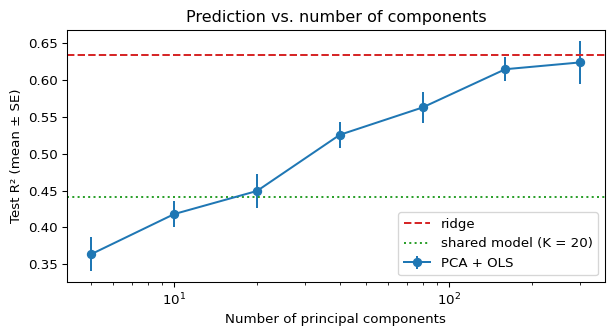

```python
pc_path = os.path.join(RESULTS, "pca_components_vs_r2.csv")
if os.path.exists(pc_path):
    pc = pd.read_csv(pc_path, index_col=0)
    display(pc.round(3))
    comp_cols = [c for c in pc.columns if c.startswith("PCA+OLS")]
    ks = [int(c.split("=")[1]) for c in comp_cols]
    fig, ax = plt.subplots(figsize=(6.5, 3.6))
    ax.errorbar(ks, pc[comp_cols].mean(), yerr=pc[comp_cols].std() / np.sqrt(len(pc)),
                marker="o", label="PCA + OLS")
    ax.axhline(pc["ridge"].mean(), color="tab:red", ls="--", label="ridge")
    ax.axhline(pc["shared (K=20)"].mean(), color="tab:green", ls=":", label="shared model (K = 20)")
    ax.set(xscale="log", xlabel="Number of principal components", ylabel="Test R² (mean ± SE)",
           title="Prediction vs. number of components")
    ax.legend()
    plt.tight_layout()
    save_fig(fig, "pca_components_vs_r2.png")
    plt.show()
```

PCA + OLS approaches ridge only with about 150–300 components, and ridge’s out-of-factor-space prediction correlates about 0.6 with the out-of-space part of TMB. So TMB’s predictive information is spread over many weak directions beyond the dominant ~20: the factor models’ shortfall is the number of factors they keep, not convergence or the choice of coefficients within their factor space. A model could capture more of it with more factors — but the shrinkage prior prunes factors that explain little of the views, which is where a larger outcome weight could let the outcome decide which weak factors to keep.

## 8. Summary of findings

Numbers refer to the October 2026 run (split seed 42, `min_epochs = 200`; comparisons over five splits). Gene-level readings are interpretations of the loadings and should be checked against the literature and, where possible, gene-set analysis.

**Prediction.** On the held-out samples the shared model explains about 44% of the variance in log(1 + TMB) (five-split mean 0.44), with 95% intervals covering about 92–93% of test samples. Training longer than 200 epochs lowers the loss further but does not change test R² (section 3b).

**The TMB signal is strong in the data.** The direction the model uses to predict TMB stands out from the noise far more (well over 100×) than the threshold at which an unsupervised method could find it, so the outcome-related variation is not hidden in these views (`docs/supervision_regimes.md`).

**What the factors capture** (rotated factors; clinical association heatmap and gene panels):

- **F3**, the factor most associated with TMB (about 20% of the outcome’s variance), is promoter hypermethylation across many genes (e.g. WNT3, MCC, NRG2, PTGER3); its scores rise with TMB and the MSI score, fall with aneuploidy, and differ strongly by molecular subtype — consistent with the CpG island methylator phenotype that accompanies microsatellite instability.
- **F1**, the second most TMB-associated factor (negative effect), is promoter methylation of intestinal and metabolic genes (e.g. XDH, PCK1, HSD17B2, with negative loadings); its scores fall with the MSI score. It is also associated with tissue source site (η² 0.27), so part of it may be batch.
- **F10** is expression of chromosome 20q genes (e.g. EIF6, RALY, HM13) and tracks aneuploidy — consistent with 20q copy-number gain in chromosomally unstable tumours, which tend to have low TMB.
- **F18** is interferon-γ / antigen-presentation expression (CXCL9, TAP2, HLA class II) — consistent with the immune infiltration of hypermutated tumours.
- **F12** (AGR2, TFF3, XBP1) suggests secretory/mucinous differentiation, **F5** (GPA33, TSPAN1, DHRS9) intestinal epithelial differentiation, and **F8** is almost entirely explained by sex.
- **F17** is the factor most associated with tissue source site (η² 0.42) and has no coherent gene programme among its top genes: likely a batch effect.

**Comparison of predictions.** Ridge (R² 0.63) and elastic net (0.59) predict TMB clearly better than every factor method; the shared model (0.44) performs like the unsupervised PCA + OLS (0.45) and MOFA + OLS (0.43). With `outcome_weight = 1` the outcome contributes one likelihood term per sample against 3 000 feature terms, so the factors are driven almost entirely by the views’ variance, as in unsupervised methods; and summarising 3 000 features in 20 factors discards predictive detail that a penalised regression keeps.

**Comparison of factors** (sections 7b–7c). The three factor methods recover essentially the same factors (subspace canonical correlations above 0.9; factor matches with MOFA |r| ≈ 0.98; predictions correlate 0.99). The shared model’s factors are about as interpretable and reproducible as MOFA’s, with no clear advantage:

- **Stability:** shared model and MOFA factors reappear almost exactly when refitted on other splits (mean best correlation 0.94; 0.98 for the main TMB factor); PCA’s are less stable (0.84; 0.75 for its main TMB factor).
- **Outcome concentration:** the shared model puts slightly more of TMB into its top factor (48% of the factors’ outcome R², vs 34% for MOFA) and needs fewer factors for 80% of it (4.4 vs 5.4); PCA is similar on average but varies much more between splits.
- **Clinical alignment:** all three find factors related to MSI, aneuploidy and subtype; PCA’s best matches are slightly stronger, and the shared model’s and MOFA’s are similar. The strongest association with tissue source site is the same for the shared model and MOFA (η² 0.32) and higher for PCA (0.38).

So on this data the supervised model behaves much like MOFA, which is expected when the outcome has almost no weight in the fit.

**Where the gap to ridge comes from** (section 7d). PCA + OLS reaches ridge’s R² only with about 150–300 components: TMB’s predictive information is spread over many weak directions beyond the ~20 that the factor models keep. Closing the gap needs more factors, and — because the shrinkage prior prunes factors that explain little of the views — probably a larger outcome weight so the outcome can keep the weak predictive ones. A cross-validated sweep over the outcome weight and the number of factors is the natural next experiment.

## Saved outputs

```python
for folder in (RESULTS, FIGURES):
    print(os.path.relpath(folder, HERE) + "/")
    for f in sorted(os.listdir(folder)):
        if os.path.isfile(os.path.join(folder, f)):
            print("   ", f)
```

```
results/
    clinical_associations.csv
    cohort_summary.csv
    compare_methods.log
    convergence_check.csv
    convergence_check.log
    convergence_loss_100.csv
    convergence_loss_1600.csv
    convergence_loss_200.csv
    convergence_loss_400.csv
    convergence_loss_800.csv
    factor_comparison_per_split.csv
    factor_comparison_summary.csv
    factor_correspondence.csv
    factor_genes_top_outcome_factors.csv
    factor_stability.csv
    factor_strength_summary.csv
    factor_summary.csv
    method_comparison_splits.csv
    method_comparison_summary.csv
    method_predictions.csv
    model_expr_meth_tss200_k20.pth
    model_expr_meth_tss200_k20_local.pth
    model_expr_meth_tss200_k20_local_paramstore.pth
    model_expr_meth_tss200_k20_paramstore.pth
    pca_components_vs_r2.csv
    render.log
    subtype_counts.csv
    test_metrics.csv
    test_prediction_correlations.csv
    test_predictions.csv
    top_genes_expression.csv
    top_genes_tss200.csv
figures/
    clinical_associations.png
    convergence_check.png
    factor_correspondence.png
    factor_genes.png
    factor_stability.png
    factor_strength.png
    loadings.png
    method_comparison.png
    outcome_distribution.png
    pca_components_vs_r2.png
    scores_vs_tmb.png
    test_predictions.png
    top_factor_by_subtype.png
    training_loss.png
    view_distributions.png
```